# C42B cells day Ola 1,5 and 9 comparisons

Marion Hardy

2025-01-16

# Introduction

BulkRNAseq analysis of C42B cells treated with olaparib at different concentrations (1-5 uM?) for different amount of times (1-9 days).

This report will present a broad overview of how similar/different samples are in terms of gene expression. The objective is to help AK narrow down which gene sets are of interest and follow this with a gsea analysis and a closer look at the function of these identified gene groups.

Each sample comparison shown in this report will have additional files generated:

- res_tbl.csv = all differentially expressed genes, annotated (no filtering)
- Sign_genes.xlsx = excel doc with all significantly up- and down-regulated genes (log2Fc >= 1), annotated and sorted into all genes, only up and only down on different sheets.
- volcano plot of all genes (html format)

NB: Data quality has been checked within the previous script “DESeq2.R”, everything looked good.

# PCA

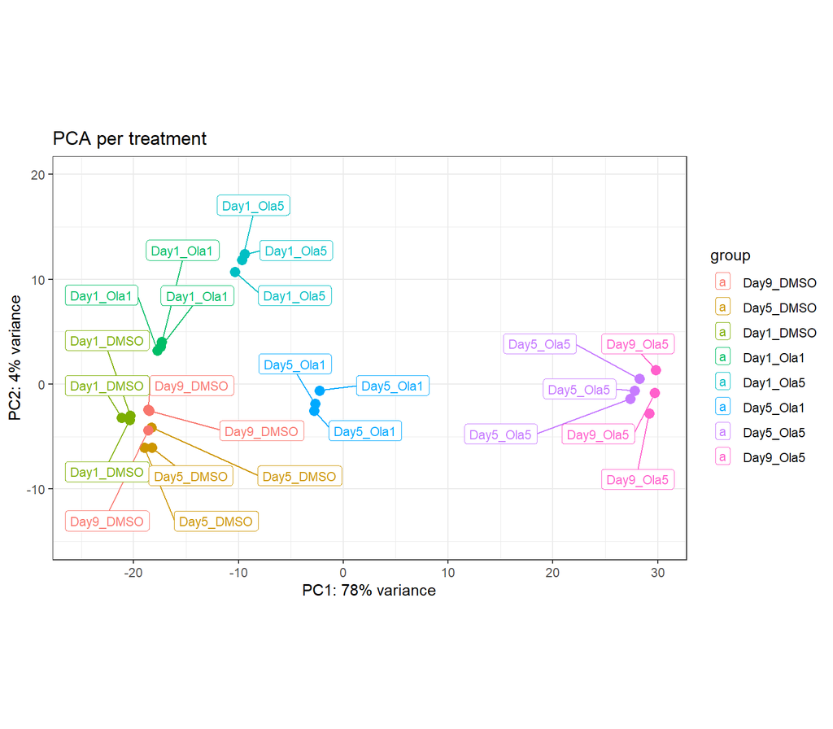

# Euclidian distances

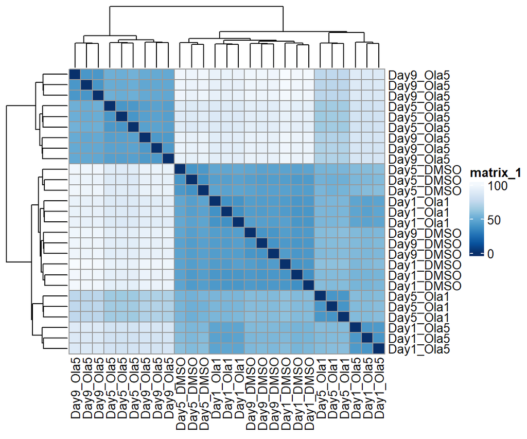

# Venn diagram on steroids (UpsetPlot)

Conditions we want to compare, per group:

- Ola 1 vs DMSO

- Ola 5 vs DMSO

I extracted all significantly differentially expressed genes (DEGs) for each condition (|log2Fc| >= 1 and pval < 0.05).

**Set size** = how many DEGs there are per sample

**Intersection size** = How many genes are shared between the x samples tied together with the bar + nodes

So if you sum up all the intersection size with a dot in a sample, you get the set size of that sample. It’s essentially a venn diagram for when you have >3 samples you want to compare.

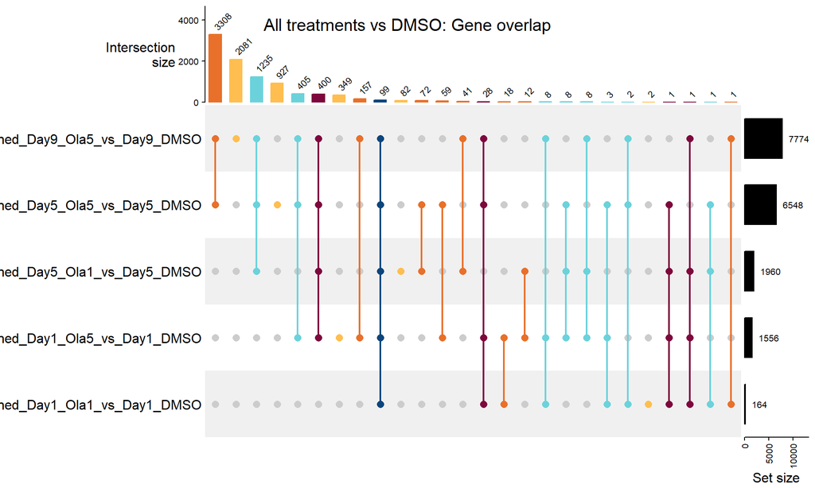

# Day1 Ola 1 and 5 vs DMSO

## Volcano plots

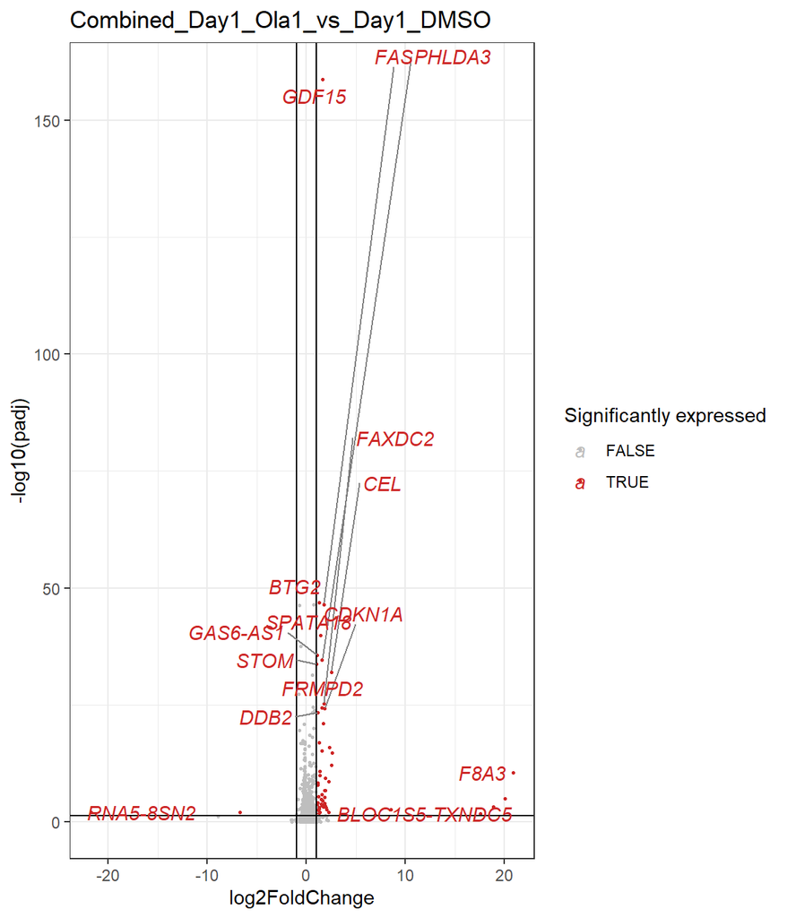

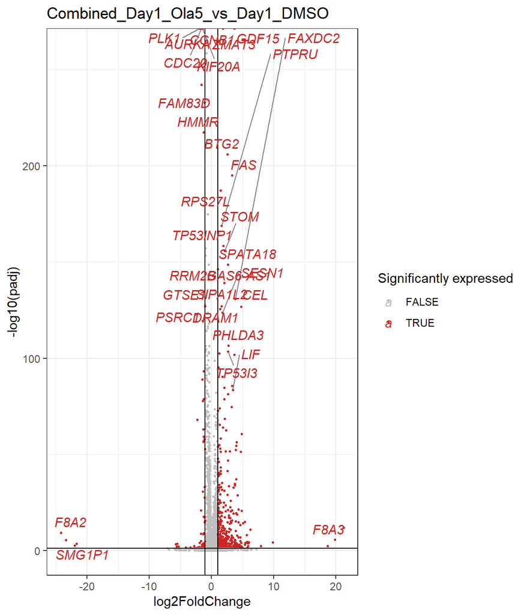

## GSEA Day1 Ola1

### GOBP

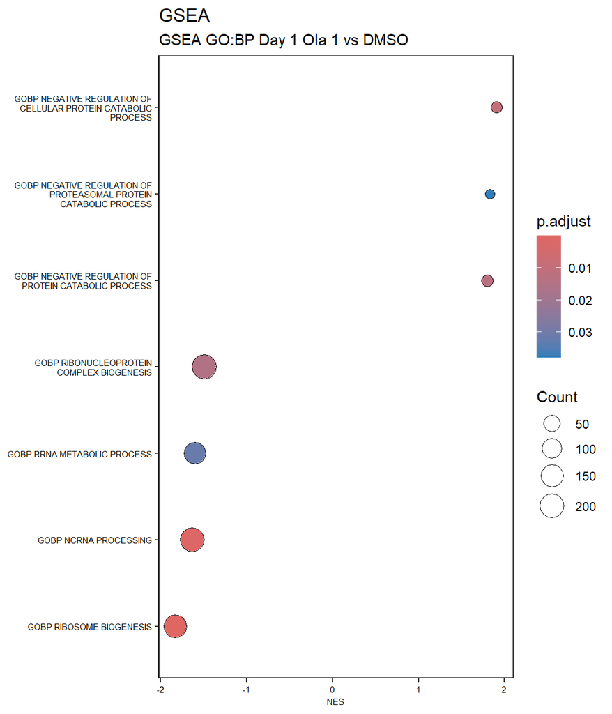

| ID | NES | setSize | p.adjust | qvalue | core_enrichment |
| --- | --- | --- | --- | --- | --- |
| GOBP_NEGATIVE_REGULATION_OF_CELLULAR_PROTEIN_CATABOLIC_PROCESS | 1.913285 | 72 | 0.0097322 | 0.0097322 | F8A3/MGAT3/PRKCG/EPHA4 |
| GOBP_NEGATIVE_REGULATION_OF_PROTEASOMAL_PROTEIN_CATABOLIC_PROCESS | 1.828282 | 45 | 0.0378612 | 0.0378612 | F8A3/PRKCG |
| GOBP_NEGATIVE_REGULATION_OF_PROTEIN_CATABOLIC_PROCESS | 1.796609 | 113 | 0.0131288 | 0.0131288 | F8A3/MGAT3/PRKCG/SNCA/NOS2/EPHA4 |
| GOBP_RIBONUCLEOPROTEIN_COMPLEX_BIOGENESIS | -1.493141 | 411 | 0.0148322 | 0.0148322 | NGDN/NVL/EXOSC10/LUC7L3/METTL16/MRPL20/CPSF6/UTP3/POLR2D/PWP…… |
| GOBP_RRNA_METABOLIC_PROCESS | -1.600452 | 243 | 0.0316196 | 0.0316196 | NGDN/GTF3C4/NVL/EXOSC10/METTL16/UTP3/PWP1/YTHDF2/FCF1/POP7/D…… |
| GOBP_NCRNA_PROCESSING | -1.630295 | 364 | 0.0011662 | 0.0011662 | NGDN/TSEN2/ELP1/NVL/EXOSC10/METTL16/UTP3/PWP1/YTHDF2/FCF1/ZB…… |
| GOBP_RIBOSOME_BIOGENESIS | -1.832311 | 280 | 0.0000178 | 0.0000178 | NGDN/NVL/EXOSC10/METTL16/MRPL20/UTP3/PWP1/GNL2/YTHDF2/FCF1/G…… |

### Reactome

no results

## GSEA Day1 Ola5

### GOBP

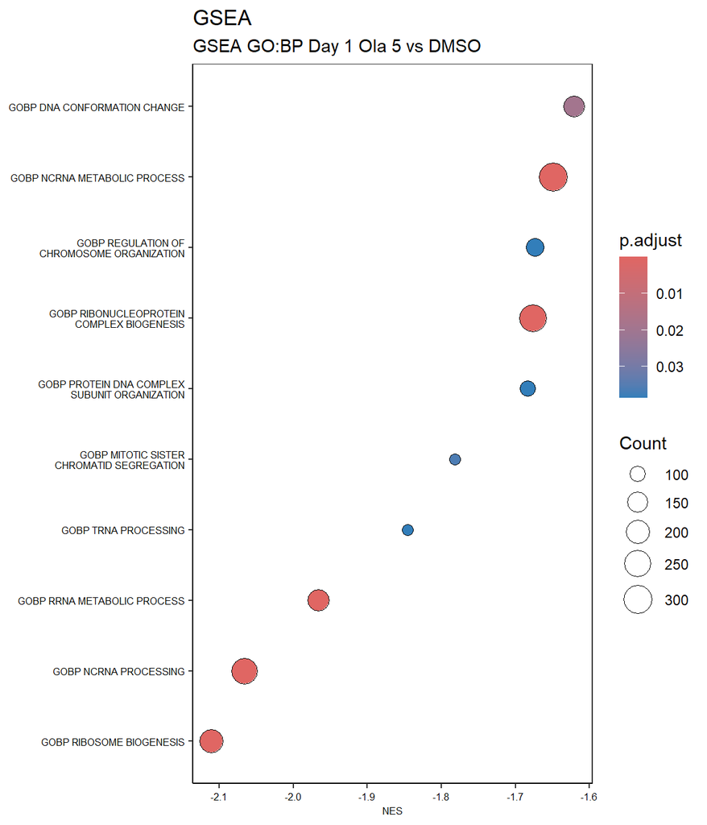

| ID | NES | setSize | p.adjust | qvalue | core_enrichment |
| --- | --- | --- | --- | --- | --- |
| GOBP_DNA_CONFORMATION_CHANGE | -1.620936 | 301 | 0.0192372 | 0.0183056 | GINS2/RESF1/HELQ/SMC5/MCM2/MCM5/NAP1L3/GINS1/SART3/FBH1/WRNI…… |
| GOBP_NCRNA_METABOLIC_PROCESS | -1.649168 | 494 | 0.0000468 | 0.0000445 | TRMT5/DDX49/ELP1/DROSHA/MEPCE/EXOSC2/CT45A1/EPRS1/AARS1/TRUB…… |
| GOBP_REGULATION_OF_CHROMOSOME_ORGANIZATION | -1.673252 | 198 | 0.0385186 | 0.0366532 | ANAPC7/CDK5RAP2/XRCC3/RAD50/INO80C/SLF1/ZWILCH/SMG1/PCID2/RE…… |
| GOBP_RIBONUCLEOPROTEIN_COMPLEX_BIOGENESIS | -1.676277 | 411 | 0.0001047 | 0.0000996 | DHX30/TGS1/CELF1/ERAL1/DDX49/DROSHA/SF3A3/EXOSC2/KHDC4/UTP3/…… |
| GOBP_PROTEIN_DNA_COMPLEX_SUBUNIT_ORGANIZATION | -1.683582 | 212 | 0.0385186 | 0.0366532 | MYC/SMARCC1/TERF1/YY1/SOX9/SUPT16H/CENPX/POLR1E/BRF2/KAT6A/S…… |
| GOBP_MITOTIC_SISTER_CHROMATID_SEGREGATION | -1.781923 | 169 | 0.0359422 | 0.0342015 | CDC23/HASPIN/NAA10/APC/CDC26/NUP62/VPS4A/PSMG2/DSCC1/SMC2/PD…… |
| GOBP_TRNA_PROCESSING | -1.845248 | 120 | 0.0385186 | 0.0366532 | ELP3/TRMT112/ZBTB8OS/MTFMT/CDK5RAP1/HSD17B10/TRMT10B/TSEN2/L…… |
| GOBP_RRNA_METABOLIC_PROCESS | -1.965539 | 243 | 0.0000030 | 0.0000029 | UTP3/METTL5/RPF1/TAF1B/NSUN4/RPP40/RRP8/GTF3C4/HELQ/POP4/MRM…… |
| GOBP_NCRNA_PROCESSING | -2.066242 | 364 | 0.0000000 | 0.0000000 | TRMT5/DDX49/ELP1/DROSHA/EXOSC2/CT45A1/AARS1/TRUB1/UTP3/METTL…… |
| GOBP_RIBOSOME_BIOGENESIS | -2.110935 | 280 | 0.0000000 | 0.0000000 | NSUN4/RPP40/RRP8/TRAF7/HELQ/POP4/FASTKD2/MRM2/NVL/RBFA/GNL2/…… |

### Reactome

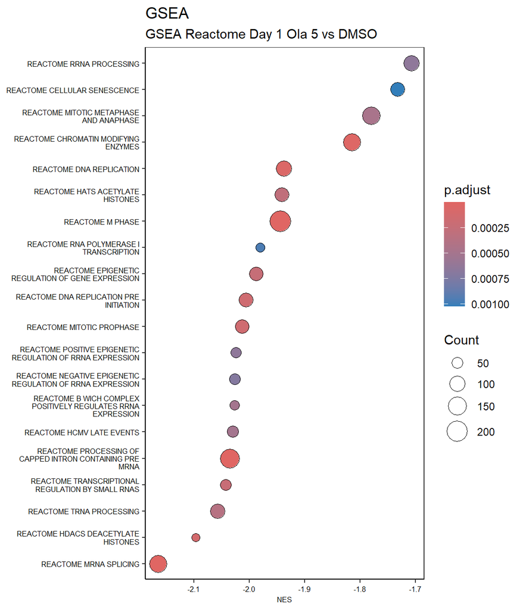

| ID | NES | setSize | p.adjust | qvalue | core_enrichment |
| --- | --- | --- | --- | --- | --- |
| REACTOME_ASPARTATE_AND_ASPARAGINE_METABOLISM | 1.723612 | 10 | 0.0048394 | 0.0041607 | ASPG/ASPA |
| REACTOME_DAP12_INTERACTIONS | 1.677562 | 33 | 0.0240919 | 0.0207133 | SIGLEC14/CD300LB/KLRK1/SIGLEC15/TREM2/LCP2/GRAP2/BTK/LAT/PLCG2/LCK |
| REACTOME_DISEASES_ASSOCIATED_WITH_O_GLYCOSYLATION_OF_PROTEINS | 1.653561 | 58 | 0.0197442 | 0.0169753 | ADAMTSL2/MUC12/THSD1/SBSPON/ADAMTS5/SEMA5B/ADAMTS7/ADAMTS14/MUC3A/ADAMTS6/NOTCH1/ADAMTS9/SEMA5A/MUC17/MUC13/THSD4/ADAMTSL4/NOTCH3/SSPOP/ADAMTSL5 |
| REACTOME_ARACHIDONIC_ACID_METABOLISM | 1.623998 | 54 | 0.0303885 | 0.0261269 | CYP4B1/CYP1A2/DPEP1/HPGDS/ALOX5AP/CYP4F3/CYP4F2/PTGS2/PTGS1/GPX2/CYP4F22/CYP4A11/ALOX12B/ALOX15B/CYP4F11/GPX1/CYP4F8/CYP1A1/PTGES |
| REACTOME_ELASTIC_FIBRE_FORMATION | 1.622248 | 43 | 0.0452519 | 0.0389059 | GDF5/FBN2/MFAP4/EFEMP2/LTBP2/LOXL4/FBN3/FBN1/EMILIN3/FBLN1/EFEMP1 |
| REACTOME_STIMULI_SENSING_CHANNELS | 1.561839 | 96 | 0.0220070 | 0.0189208 | TRPV2/CASQ1/TRPC7/STOM/CLCNKB/ANO1/TRPM3/SLC9C2/SCNN1G/TRPV4…… |
| REACTOME_EXTRACELLULAR_MATRIX_ORGANIZATION | 1.539091 | 278 | 0.0017433 | 0.0014988 | NID1/COL17A1/SERPINE1/CEACAM1/GDF5/COL5A1/PECAM1/ITGAM/MUSK/…… |
| REACTOME_DEGRADATION_OF_THE_EXTRACELLULAR_MATRIX | 1.519040 | 124 | 0.0243330 | 0.0209206 | NID1/COL17A1/COL5A1/FBN2/TMPRSS6/CAPN11/COL10A1/ADAMTS5/OPTC…… |
| REACTOME_ION_CHANNEL_TRANSPORT | 1.475528 | 169 | 0.0300336 | 0.0258218 | TRPV2/FXYD2/CASQ1/TRPC7/FXYD6/ATP13A4/ATP10D/STOM/CLCNKB/ANO…… |
| REACTOME_ESR_MEDIATED_SIGNALING | -1.367895 | 204 | 0.0469693 | 0.0403825 | BCL2/GNB4/STRN/KANK1/AKT1/H2BC21/TLE3/SMC3/H4C5/AGO2/KDM1A/XPO1/RUNX1/H4C11/TBP/H3-3B/H2BC5/H4C2/CHD1/GTF2A1/H3C12/PTGES3/PPID/H2BC15/H2AZ1/EBAG9/HSP90AB1/HSP90AA1/PRMT1/FKBP4/MYB/STAG1/RAD21/H4C8/H2B… |
| REACTOME_TRANSCRIPTIONAL_REGULATION_BY_RUNX1 | -1.393962 | 204 | 0.0333640 | 0.0286851 | PSMC5/GPAM/ARID1B/SMARCC1/PSMC2/PSMD10/KMT2B/CCND1/PSMD5/PSM…… |
| REACTOME_RHO_GTPASE_EFFECTORS | -1.415516 | 303 | 0.0303184 | 0.0260666 | CENPC/PFN1/PKN1/PPP1R12A/CLASP2/YWHAG/SKA2/DIAPH1/MEN1/MRTFA…… |
| REACTOME_HIV_LIFE_CYCLE | -1.453456 | 136 | 0.0407092 | 0.0350003 | TAF3/TAF12/SUPT4H1/UBAP1/POLR2J/GTF2B/ERCC3/CHMP4C/VPS37B/XR…… |
| REACTOME_RHO_GTPASES_ACTIVATE_FORMINS | -1.503672 | 135 | 0.0363145 | 0.0312219 | CENPC/PFN1/CLASP2/SKA2/DIAPH1/MRTFA/MAPRE1/PPP2R5C/PPP2R1B/S…… |
| REACTOME_G2_M_CHECKPOINTS | -1.543595 | 147 | 0.0333789 | 0.0286979 | RFC4/PSMD9/PSMC3/SUMO1/PSMD8/RAD1/PSMF1/PSMB5/PIAS4/KAT5/PSM…… |
| REACTOME_SYNTHESIS_OF_DNA | -1.546757 | 112 | 0.0243330 | 0.0209206 | RFC4/PSMD9/PSMC3/PSMD8/PSMF1/PSMB5/PSMB7/PSMA2/RFC1/RFC3/PSM…… |
| REACTOME_TRANSLATION | -1.623176 | 278 | 0.0029066 | 0.0024990 | DARS2/MRPL32/RPL27/EIF2S3/RPS23/RPL21/EEF1A1/RPL4/RPL34/CARS…… |
| REACTOME_CELL_CYCLE_CHECKPOINTS | -1.627389 | 266 | 0.0012329 | 0.0010600 | MCM2/PSMA6/PSMA1/MCM5/UBC/PAFAH1B1/CDKN1B/MCM4/CDK1/PSMC5/ND…… |
| REACTOME_MITOTIC_PROMETAPHASE | -1.630710 | 189 | 0.0019045 | 0.0016375 | CEP78/PPP2R1A/TUBGCP2/CEP43/CEP192/CENPC/CLASP2/YWHAG/SKA2/M…… |
| REACTOME_TELOMERE_MAINTENANCE | -1.641528 | 99 | 0.0285186 | 0.0245192 | DSCC1/H2AC14/POLR2B/RUVBL2/PPP6R3/POT1/H2BC21/SHQ1/H4C5/WRAP53/H4C11/H3-3B/H2BC5/H4C2/H2BC15/H2AZ1/DKC1/GAR1/H4C8/H2BC6/TERT/H2AC20/H2BC14/H2BC13/H2BC7/H2AX/H2BC4/CCNA1/CCNA2/H4C14/H2BC12/H2AC8/H2BC17… |
| REACTOME_PRE_NOTCH_EXPRESSION_AND_PROCESSING | -1.648427 | 95 | 0.0117659 | 0.0101159 | TMED2/H2BC21/H4C5/AGO2/E2F3/RUNX1/H4C11/H3-3B/H2BC5/H4C2/H3C12/H2BC15/H2AZ1/H4C8/H2BC6/H2AC20/H2BC14/H3C15/H3C2/H3C1/H2BC13/H2BC7/H2AX/H2BC4/H4C14/H2BC12/H2AC8/H2BC17/H2AC7/H3C10/H2AC6/H4C15/H2BC11/MF… |
| REACTOME_TRANSPORT_OF_MATURE_TRANSCRIPT_TO_CYTOPLASM | -1.648671 | 82 | 0.0243330 | 0.0209206 | SARNP/CPSF3/SRRM1/SRSF5/NUP43/NUP107/NXF1/SRSF4/SLBP/TPR/DHX…… |
| REACTOME_RESOLUTION_OF_SISTER_CHROMATID_COHESION | -1.651576 | 121 | 0.0071228 | 0.0061239 | MAPRE1/PPP2R5C/PPP2R1B/KIF2A/PPP2CA/TUBA3D/PDS5A/DYNLL2/WAPL…… |
| REACTOME_TRANSCRIPTIONAL_REGULATION_OF_GRANULOPOIESIS | -1.667775 | 79 | 0.0135654 | 0.0116630 | H4C5/CEBPA/RUNX1/H4C11/H3-3B/DEK/H2BC5/H4C2/H3C12/GATA2/H2BC15/H2AZ1/MYB/H4C8/H2BC6/H2AC20/H2BC14/H3C15/H3C2/H3C1/H2BC13/H2BC7/H2AX/H2BC4/H4C14/H2BC12/H2AC8/H2BC17/H2AC7/TAL1/H3C10/H2AC6/H4C15/H2BC11/… |
| REACTOME_CHROMOSOME_MAINTENANCE | -1.698055 | 126 | 0.0041945 | 0.0036063 | PPP6C/TERF1/NOP10/POLR2D/CENPX/POLA1/CENPW/CENPC/POLR2G/RBBP7/ANKRD28/PRIM1/POLR2C/DSCC1/H2AC14/POLR2B/RUVBL2/PPP6R3/POT1/CENPO/H2BC21/OIP5/SHQ1/H4C5/WRAP53/CENPI/H4C11/H3-3B/H2BC5/H4C2/H2BC15/H2AZ1/M… |
| REACTOME_RHO_GTPASES_ACTIVATE_PKNS | -1.699004 | 81 | 0.0125629 | 0.0108011 | H2BC21/YWHAH/H4C5/KDM1A/KLK3/H4C11/H3-3B/H2BC5/H4C2/H3C12/H2BC15/H2AZ1/H4C8/H2BC6/H2AC20/H2BC14/H3C15/H3C2/H3C1/H2BC13/H2BC7/H2AX/H2BC4/H4C14/H2BC12/H2AC8/H2BC17/H2AC7/H3C10/H2AC6/H4C15/H2BC11/H2BC8/H… |
| REACTOME_RRNA_PROCESSING | -1.707111 | 191 | 0.0006529 | 0.0005613 | DDX49/EXOSC2/UTP3/NOL12/NSUN4/RPP40/MRM2/RPL36AL/EXOSC10/DIS…… |
| REACTOME_SEPARATION_OF_SISTER_CHROMATIDS | -1.710129 | 178 | 0.0019653 | 0.0016897 | NUP43/NUP107/PSMD13/ZWILCH/CENPN/STAG2/PSMA6/PSMA1/UBC/PAFAH…… |
| REACTOME_GENE_SILENCING_BY_RNA | -1.724128 | 125 | 0.0031852 | 0.0027386 | SEC13/NUP188/NUP54/NUP160/NUP153/H2BC21/H4C5/AGO2/XPO5/NUP50/ELAC2/NUP37/NUP88/POM121/NUP205/H4C11/H3-3B/H2BC5/SEH1L/H4C2/H3C12/NUP98/NUP58/RAN/H2BC15/NDC1/H2AZ1/HSP90AA1/TDRD12/H4C8/H2BC6/H2AC20/H2BC… |
| REACTOME_CELLULAR_SENESCENCE | -1.731363 | 176 | 0.0010268 | 0.0008828 | EZH2/SCMH1/UBN1/RBBP7/MAP2K3/CDC23/MAPK1/UBE2E1/CDC26/MAP2K4/TFDP1/RPS6KA3/ID1/HIRA/HMGA1/H2AC14/FZR1/ERF/UBE2D1/CDKN2A/POT1/ETS2/H2BC21/CBX2/H4C5/E2F3/ASF1A/CBX4/H4C11/H3-3B/ANAPC1/H2BC5/H4C2/H3C12/C… |

[output cut: 70 more lines]